# CoVaRR-Net

Genomic epidemiology analyses and mathematical modelling notebook

Pillar 6

January 27, 2022

### Contributing authors:

Data analysis, code, and maintenance of this notebook: Carmen Lia Murall, Raphaël Poujol, Susanne Kraemer, Arnaud N’Guessan, Art Poon, Jesse Shaprio

Sequence collection, generation, and distribution: Canadian laboratories across the country are making these data publicly available. A complete list of lab authors is in this repository and more details are below in the Acknowledgement section.

# Introduction

This notebook is to explore Canadian SARS-CoV-2 genomic and epidemiological data, for discussion with pillar 6’s team and for sharing with collaborators. These analyses can spur further research within or across pillars, be used for reports (or data dashboards), given to the science communication pillar for public dissemination, and the code can be repackaged to give to public health authorities for their internal use.

Canadian genomic and epidemiological data will be regularly pulled from various public sources (see list below) to keep these analyses up-to-date. Only representations of aggregate data will be posted here.

```r
## 1. LOAD processed metadata of Canadian sequences (with latest pangolin, division, and full seq IDs)
#Download metadata from gisaid, put the date here:
gisaiddate="2022_01_26"
#date=2022_01_26
#tar -axf metadata_tsv_$date.tar.xz metadata.tsv -O | tr ' ' '_'  | sed 's/\t\t/\tNA\t/g' | sed 's/\t\t/\tNA\t/g' | sed 's/\t$/\tNA/g' | awk 'NR==1 || substr($1,9,6)=="Canada" && $8=="Human"' | sort -k3,3 > metadata_CANall_$date.uncorrected.csv
#cat metadata_virrusseq_$date.tsv | tr ' ' '_'  | sed 's/\t\t/\tNA\t/g' | sed 's/\t\t/\tNA\t/g' | sed 's/\t$/\tNA/g' | awk 'NR!=1 && $43!="NA"' | cut -f5,43 | sort -k2,2 | uniq > epidatesfromvirrusseq
#join -1 3 metadata_CANall_$date.uncorrected.csv -a 1 -2 2 epidatesfromvirrusseq | awk '$4!=$23 && length($4)<10 && length($23)==10{$4=$23} {id=$1;$1=$2;$2=$3;$3=id} {print}' | tr ' ' '\t'| cut -f-22 > metadata_CANall_$date.csv
#zip /media/rp/partition4data/Dropbox/Raph/covarrnet/essai2/CoVaRRNet_pillar6notebook/data_needed/metadata_CANall_$date.zip metadata_CANall_$date.csv

metaCANall <- read.csv(unz(paste("./data_needed/metadata_CANall_",gisaiddate,".zip",sep=""),paste("metadata_CANall_",gisaiddate,".csv",sep="")),sep="\t",row.names=NULL)
metaCANall$Collection_date <- as.Date(metaCANall$Collection_date)
#max(metaCANall$Collection.date) - min(metaCANall$Collection.date) #time diff: 580 days

#make a pango.group column

metaCANall$pango.group <- metaCANall$Variant
metaCANall$pango.group[is.na(metaCANall$pango.group)]<-"other"
metaCANall$pango.group[grepl("B\\.1\\.1\\.7|Q\\.", metaCANall$Pango_lineage)] <- "Alpha"
metaCANall$pango.group[grepl("B\\.1\\.351", metaCANall$Pango_lineage)] <- "Beta"
metaCANall$pango.group[grepl("P\\.", metaCANall$Pango_lineage)] <- "Gamma"
metaCANall$pango.group[grepl("B\\.1\\.617|AY\\.", metaCANall$Pango_lineage)] <- "Delta"
metaCANall$pango.group[metaCANall$Pango_lineage == "AY.25" ]<-"Delta AY.25"
metaCANall$pango.group[metaCANall$Pango_lineage == "AY.27" ]<-"Delta AY.27"
metaCANall$pango.group[grepl("C\\.37|C\\.37\\.1", metaCANall$Pango_lineage)] <- "Lambda"
metaCANall$pango.group[grepl("B\\.1\\.1\\.529|BA\\.", metaCANall$Pango_lineage)] <- "Omicron"
metaCANall$pango.group[metaCANall$Pango_lineage == "BA.1.1" ]<-"Omicron BA.1.1"
metaCANall$pango.group[metaCANall$Pango_lineage == "BA.2" ]<-"Omicron BA.2"
metaCANall$pango.group[grepl("B\\.1\\.621", metaCANall$Pango_lineage)] <- "Mu"
metaCANall$pango.group[str_detect(metaCANall$pango.group,"V") ]<-"other"
metaCANall$pango.group[metaCANall$Pango_lineage == "A.23.1" ]<-"A.23.1"
metaCANall$pango.group[metaCANall$Pango_lineage == "B.1.438.1" ]<-"B.1.438.1"

## 2. LOAD epidemiological data (PHAC)



epidataCANall <- read.csv(url("https://health-infobase.canada.ca/src/data/covidLive/covid19-download.csv"))
#from: https://health-infobase.canada.ca/covid-19/epidemiological-summary-covid-19-cases.html?stat=num&measure=total&map=pt#a2
epidate = tail(epidataCANall,1)$date
#epidataAlberta <- epidataCANall[ which(epidataCANall$prnameFR=='Alberta'), ]
#print(epidataAlberta$numtoday)
```

# Snapshot: SARS-CoV-2 in Canada

## Variants in Canada

```r
# --- Histogram plot: counts per variant of all canadian data -------------


listpango <- unique(metaCANall$pango.group)
print(listpango)
```

```
##  [1] "other"          "B.1.438.1"      "A.23.1"         "Alpha"
##  [5] "Gamma"          "Beta"           "Delta"          "Lambda"
##  [9] "Delta AY.27"    "Delta AY.25"    "Mu"             "Omicron"
## [13] "Omicron BA.1.1" "Omicron BA.2"
```

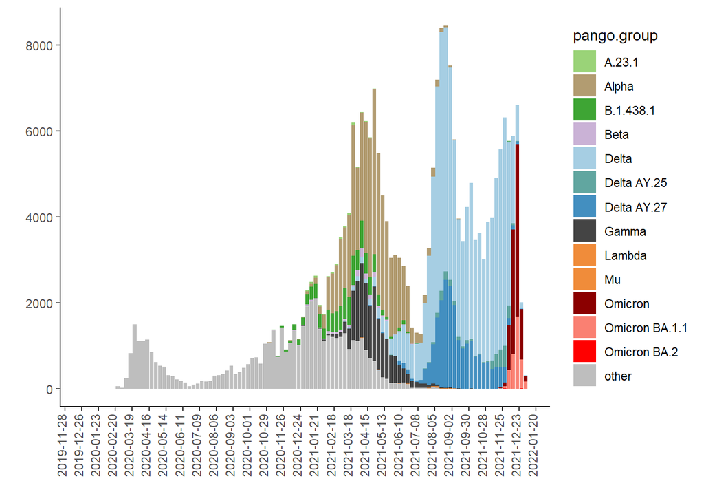

```r
listpango <- listpango[order(listpango)]
getpal <- colorRampPalette(brewer.pal(9, "Paired")) #"Set3
pal <- getpal(length(listpango))
names(pal) <- listpango
pal["Omicron"]="#8B0000"
pal["Omicron BA.1.1"]="#Fa8072"
pal["Omicron BA.2"]="#FF0000"
pal["other"]="grey"
pal["Alpha"]="#B29C71"
pal["Delta"]="#A6CEE3"
pal["Delta AY.27"]="#438FC0"
pal["Delta AY.25"]="#61A6A0"
pal["A.23.1"]="#9AD378"
pal["B.1.438.1"]="#3EA534"
pal["Beta"]="#CAB2D6"
pal["Gamma"]="#444444"
pal["Lambda"]="#F08C3A"
pal["Mu"]="#F08C3A"

#print(pal)

#------------- counts over time (by week)

plot_metadatadf <- function(meta_tab,pal) {
  meta_tab <- filter(meta_tab, !is.na(meta_tab$Collection_date))
  df1 <- meta_tab %>% group_by(pango.group) %>% group_by(week = cut(Collection_date, "week")) #adds week coloum
  dfcount <- df1 %>% group_by(week) %>% count(pango.group)
  #plot
  ggplot(dfcount, aes(x=as.Date(week), y= n, fill=pango.group))+geom_bar(stat = "identity")+
    scale_fill_manual(breaks=listpango, values = pal)+ ylab("")+xlab("")+
    scale_x_date(date_breaks = "28 day")+
    theme_classic()+theme(axis.text.x = element_text(angle=90, vjust=0.1,hjust=0.1))

}

plot_metadatadf_freq <- function(meta_tab,pal) {
  meta_tab <- filter(meta_tab, !is.na(meta_tab$Collection_date))
  df1 <- meta_tab %>% group_by(pango.group) %>% group_by(week = cut(Collection_date, "week")) #adds week coloum
  dfcount <- df1 %>% group_by(week) %>% count(pango.group)
  dfcount %>% mutate(freq = prop.table(n)) -> dfprop

  #plot
  ggplot(dfprop, aes(x= as.Date(week), y=freq, fill=pango.group))+geom_bar(stat = "identity")+
    scale_fill_manual(breaks=listpango, values = pal)+ ylab("")+xlab("")+
    scale_x_date(date_breaks = "28 day")+
    theme_classic()+theme(axis.text.x = element_text(angle=90, vjust=0.1,hjust=0.1))
}


plot_metadatadf(metaCANall,pal)
```

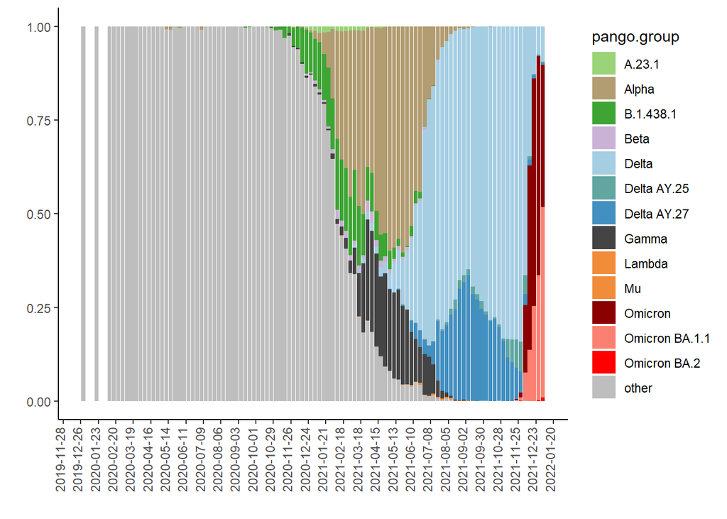

```r
plot_metadatadf_freq(metaCANall,pal)
```

There are two PANGO lineages that have a Canadian origin and have predominately spread within Canada (with some exportations internationally): B.1.438.1 and B.1.1.176.

Other lineages of Canadian interest:

- A.2.5.2 - an A lineage (clade 19B) that spread in Quebec, involved in several outbreaks, before Delta arrived
- B.1.2 - an American (USA) lineage that spread well in Canada
- B.1.160 - an European lineages that spread well in Canada

## Provinces

Here we show the same plots but for each provinces

```r
loc=sapply(strsplit(metaCANall$Location,"_/_"), `[`, 3)
metaCANall$province <- loc
print(unique(metaCANall$province))
```

```
##  [1] "Quebec"                    "Ontario"
##  [3] "Newfoundland_and_Labrador" "Nova_Scotia"
##  [5] "New_Brunswick"             "Manitoba"
##  [7] "Alberta"                   "British_Columbia"
##  [9] "Saskatchewan"              NA
## [11] "Newfoundland"
```

### British_Columbia

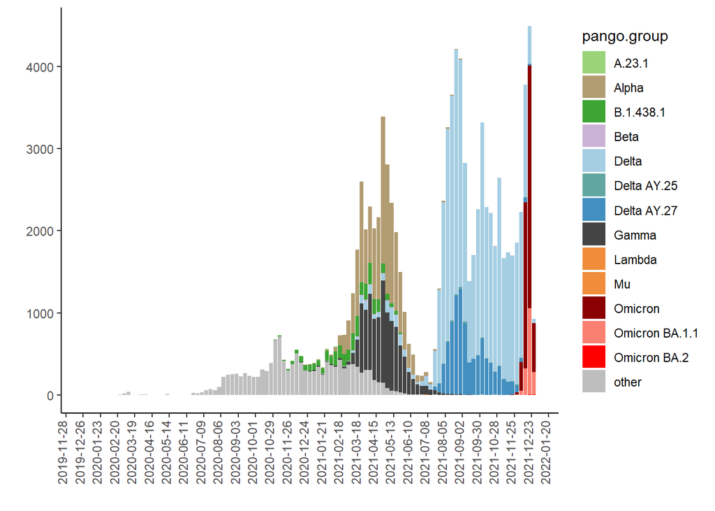

```r
plot_metadatadf(metaCANall[ which(metaCANall$province=='British_Columbia'), ],pal)
```

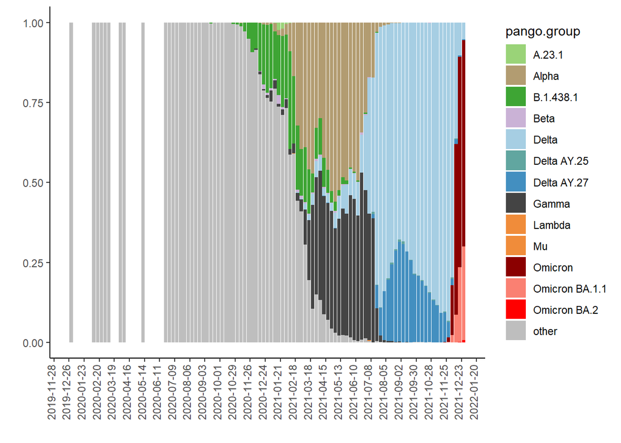

```r
plot_metadatadf_freq(metaCANall[ which(metaCANall$province=='British_Columbia'), ],pal)
```

### Alberta

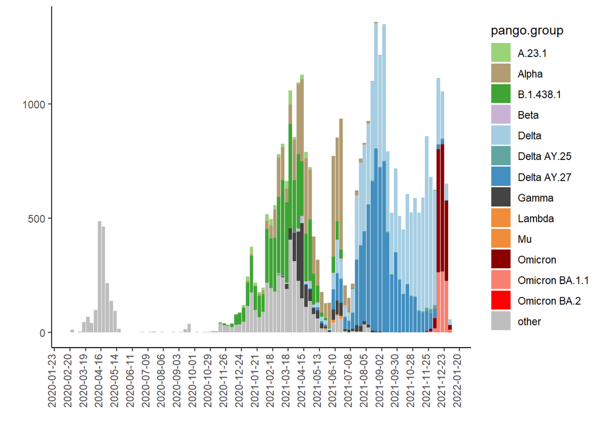

```r
plot_metadatadf(metaCANall[ which(metaCANall$province=='Alberta'), ],pal)
```

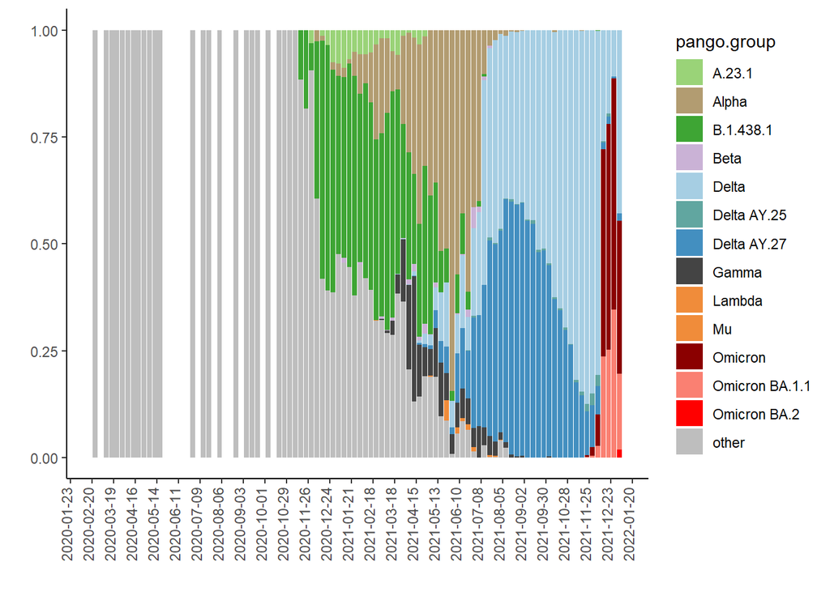

```r
plot_metadatadf_freq(metaCANall[ which(metaCANall$province=='Alberta'), ],pal)
```

### Saskatchewan

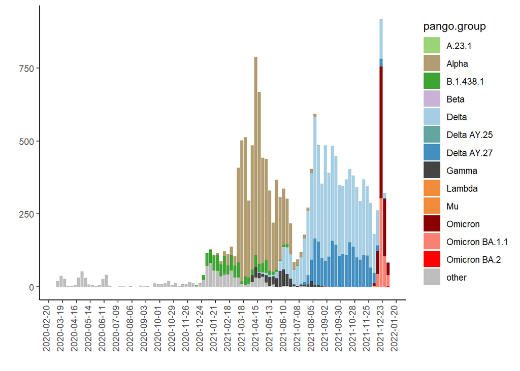

```r
plot_metadatadf(metaCANall[ which(metaCANall$province=='Saskatchewan'), ],pal)
```

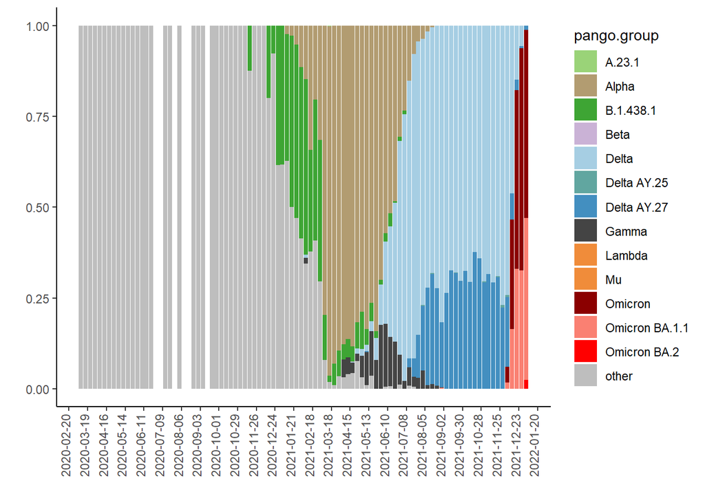

```r
plot_metadatadf_freq(metaCANall[ which(metaCANall$province=='Saskatchewan'), ],pal)
```

### Manitoba

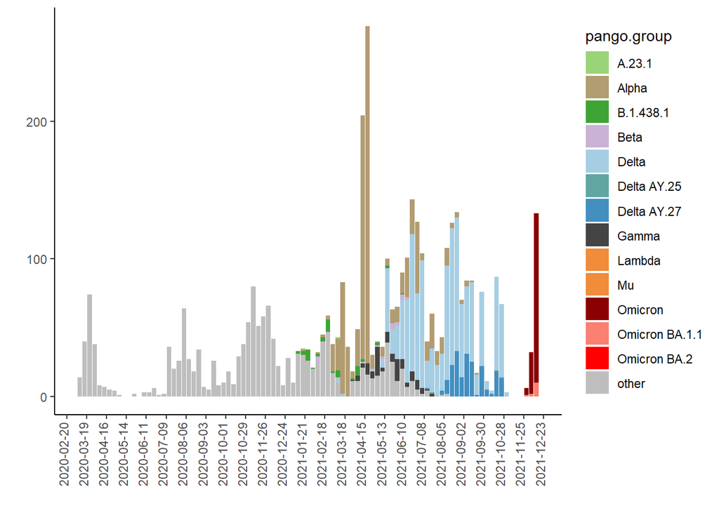

```r
plot_metadatadf(metaCANall[ which(metaCANall$province=='Manitoba'), ],pal)
```

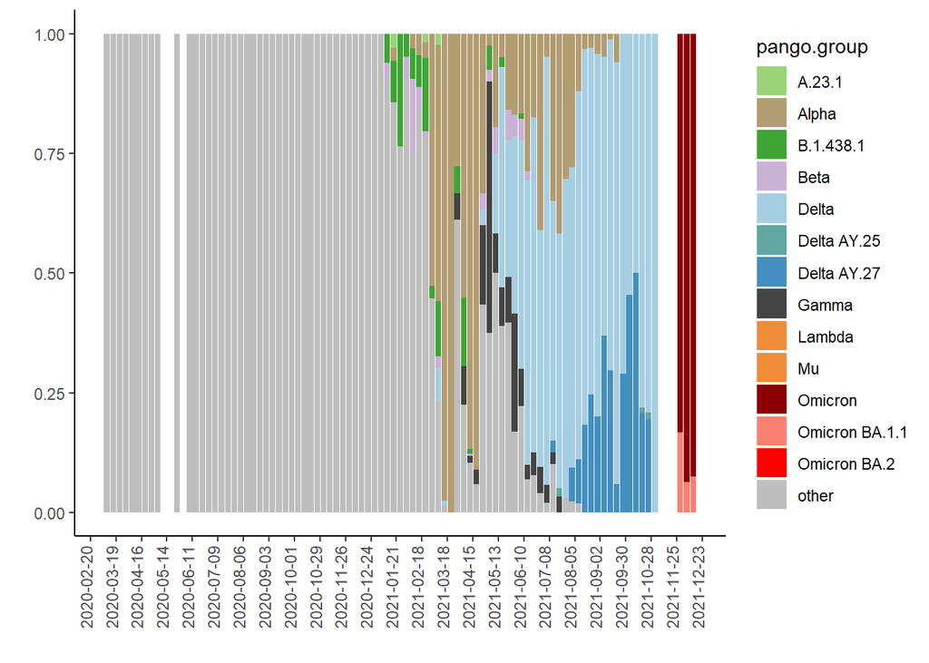

```r
plot_metadatadf_freq(metaCANall[ which(metaCANall$province=='Manitoba'), ],pal)
```

### Ontario

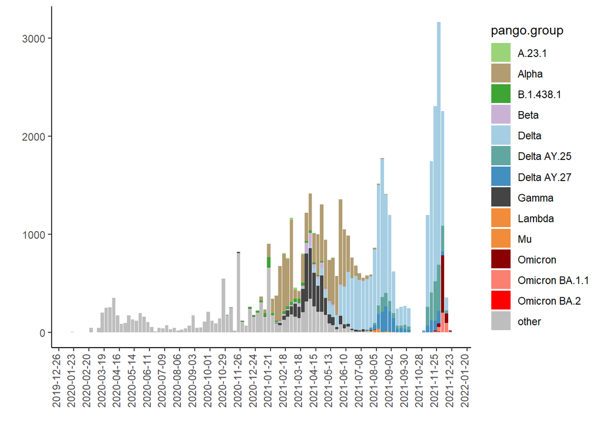

```r
plot_metadatadf(metaCANall[ which(metaCANall$province=='Ontario'), ],pal)
```

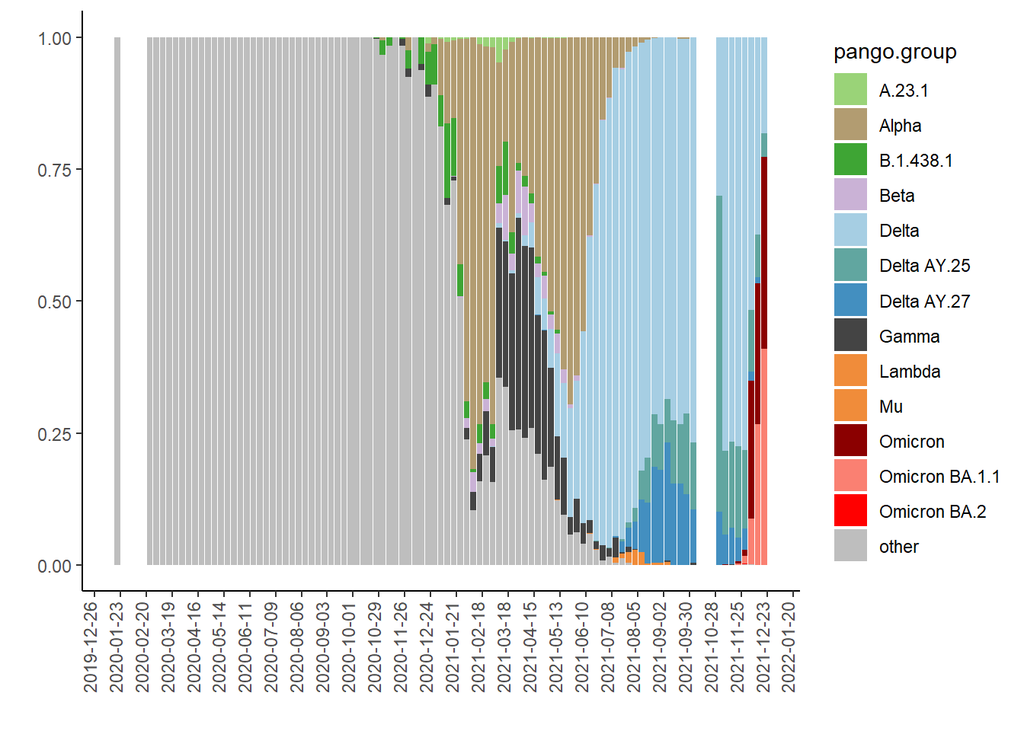

```r
plot_metadatadf_freq(metaCANall[ which(metaCANall$province=='Ontario'), ],pal)
```

### Quebec

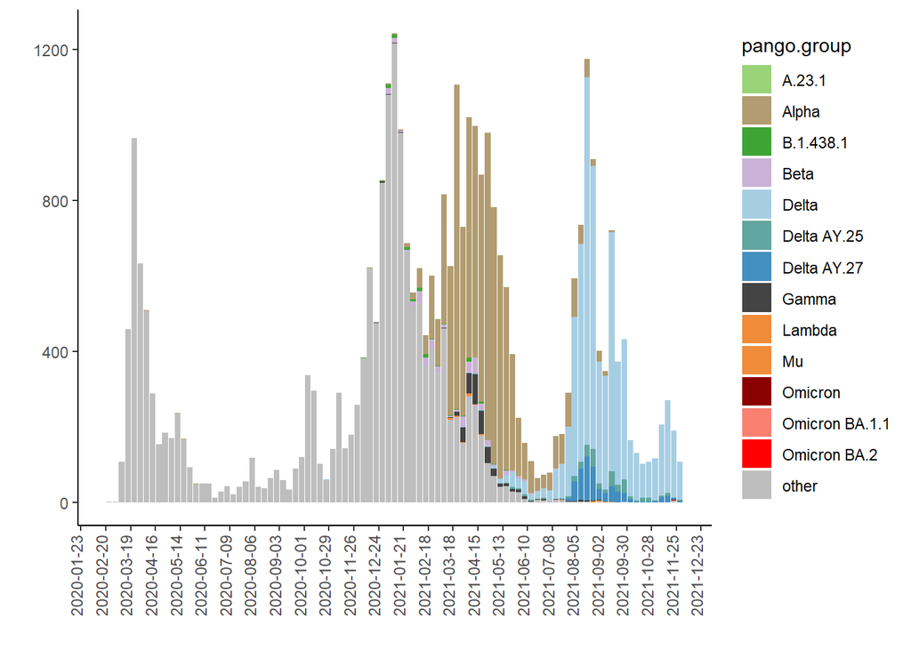

```r
plot_metadatadf(metaCANall[ which(metaCANall$province=='Quebec'), ],pal)
```

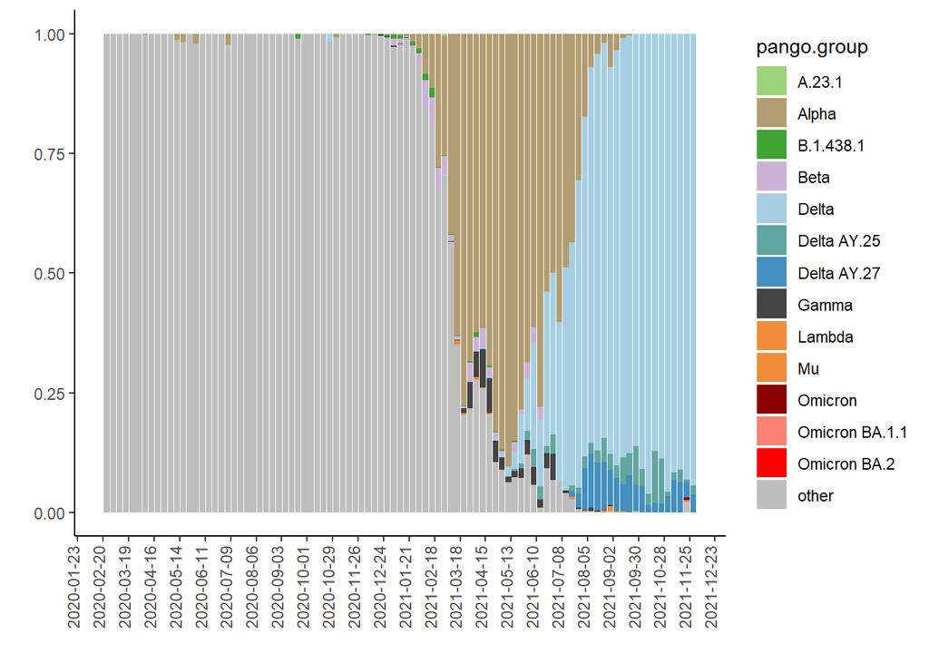

```r
plot_metadatadf_freq(metaCANall[ which(metaCANall$province=='Quebec'), ],pal)
```

### Nova_Scotia

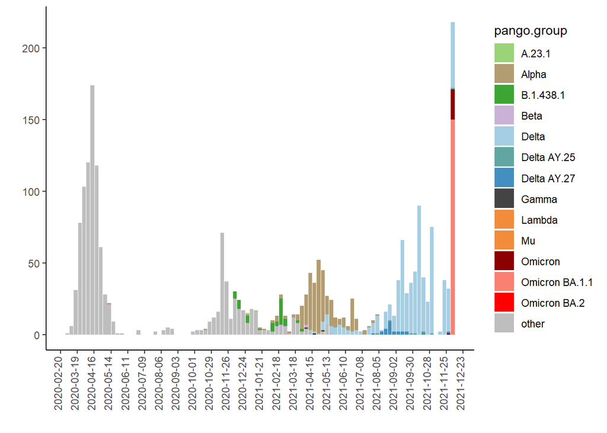

```r
plot_metadatadf(metaCANall[ which(metaCANall$province=='Nova_Scotia'), ],pal)
```

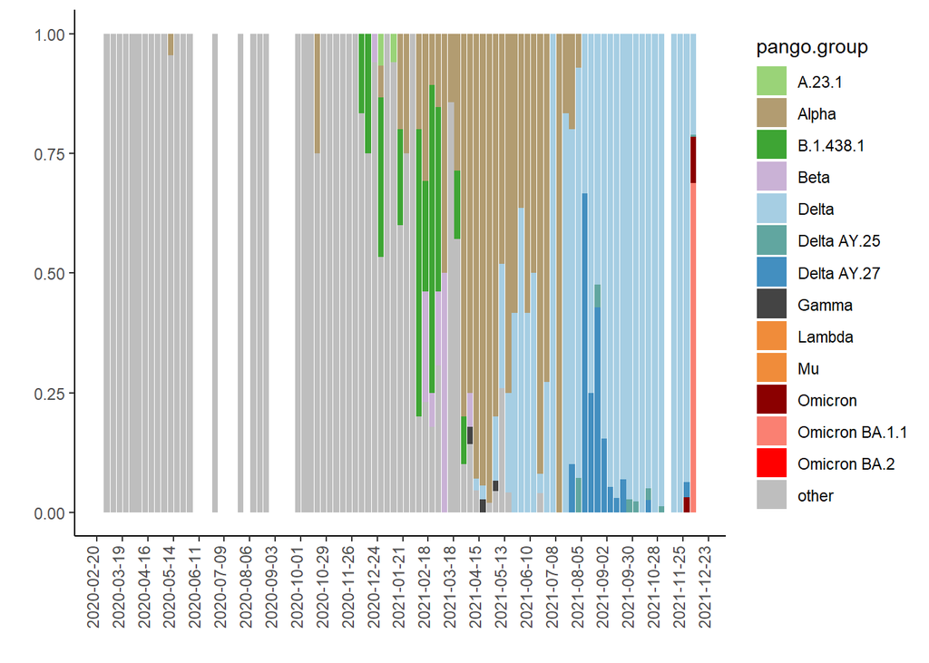

```r
plot_metadatadf_freq(metaCANall[ which(metaCANall$province=='Nova_Scotia'), ],pal)
```

### New_Brunswick

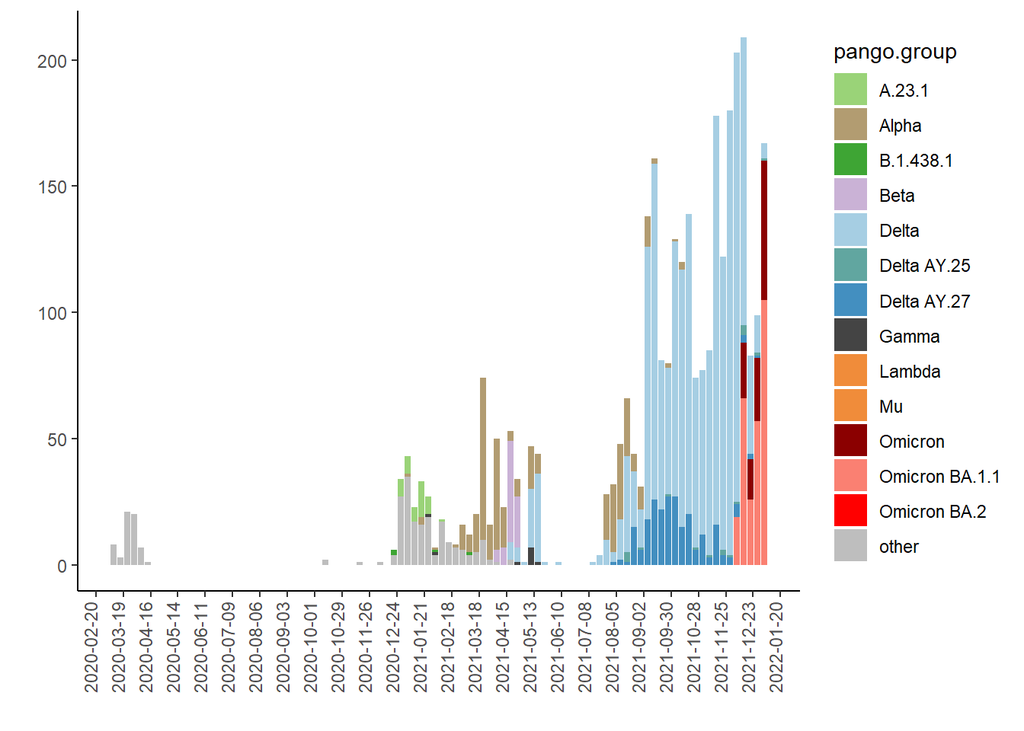

```r
plot_metadatadf(metaCANall[ which(metaCANall$province=='New_Brunswick'), ],pal)
```

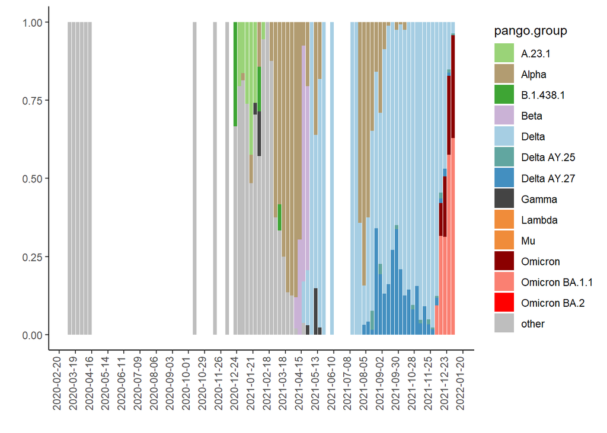

```r
plot_metadatadf_freq(metaCANall[ which(metaCANall$province=='New_Brunswick'), ],pal)
```

### Newfoundland_and_Labrador

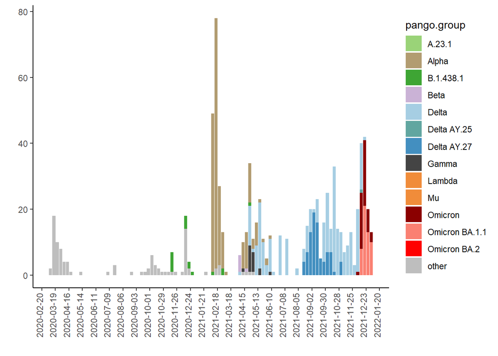

```r
subtab=metaCANall[ which(metaCANall$province=='Newfoundland' | metaCANall$province=='Newfoundland_and_Labrador' ), ]
plot_metadatadf(subtab,pal)
```

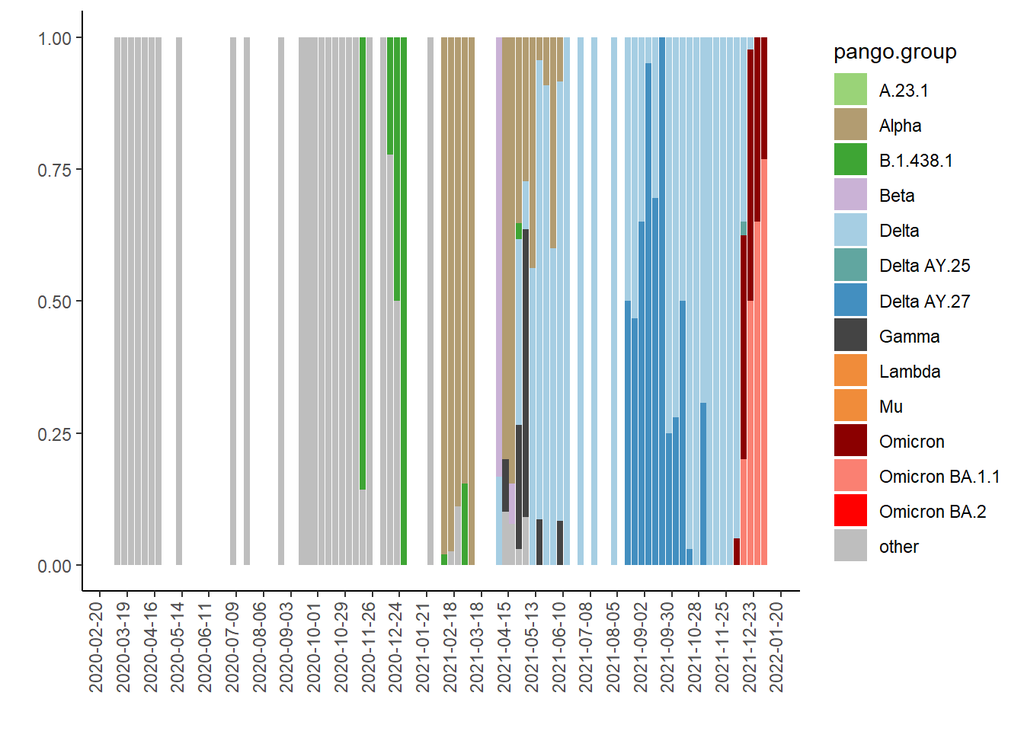

```r
plot_metadatadf_freq(subtab,pal)
```

## Canadian trees

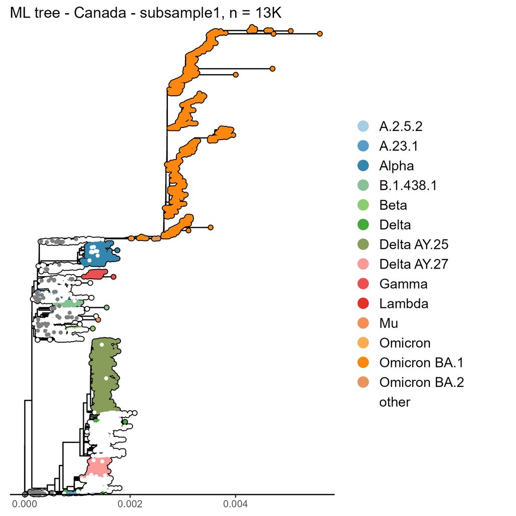

## Evolution and growth rates of SARS-CoV-2 in Canada

There are various methods to investigate changes in evolutionary rates of VOC/VOIs and compare their relative fitness in an epidemiological context.

For example, root-to-tip plots give estimates of substitution rates. Clusters with stronger positive slopes than the average SARS-CoV-2 dataset, are an indication that they are accumlating mutations at a faster pace, or clusters that jump up above the average could indicate a mutational jump (simlar to what we saw with Alpha when it first appeared in the UK).

Maximum likelihood tree ([IQ-TREE](http://www.iqtree.org/)) processed with [root-to-tip regression](https://search.r-project.org/CRAN/refmans/ape/html/rtt.html) and plotting in R.

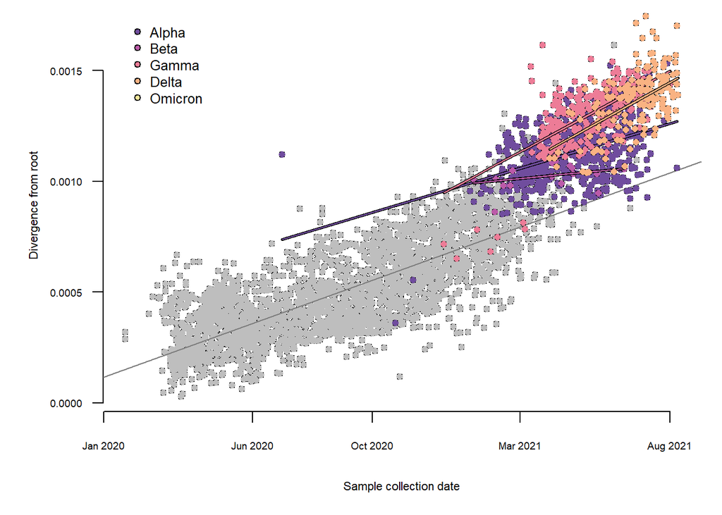

```r
#RTT code contributed by Art Poon
rooted <- read.tree('./data_needed/msa_0908_CANall_downsamp10perday_1.rtt.nwk')
get.dates <- function(phy, delimiter='_', pos=-1, format='%Y-%m-%d') {
  dt <- sapply(phy$tip.label, function(x) {
    tokens <- strsplit(x, delimiter)[[1]]
    if (pos < 0) { return(tokens[length(tokens)+pos+1]) }
    else { return(tokens[pos]) }
  })
  as.Date(dt, format=format)
}
tip.dates <- get.dates(rooted, pos=-2)

# total branch length from root to each tip
div <- node.depth.edgelength(rooted)[1:Ntip(rooted)]

# match tips to metadata to retrieve PANGO lineage assignments
accno <- gsub(".+_(EPI_ISL_[0-9]+)_.+", "\\1", rooted$tip.label)
index <- match(accno, metaCANall$Accession_ID)
pg <- metaCANall$pango.group[index]

blobs <- function(x, y, col, cex=1) {
  points(x, y, pch=21, cex=cex)
  points(x, y, bg=col, col=rgb(0,0,0,0), pch=21, cex=cex)
}
dlines <- function(x, y, col) {
  lines(x, y, lwd=2.5)
  lines(x, y, col=col)
}

vocs <- c('Alpha', 'Beta', 'Gamma', 'Delta', 'Omicron')
pal <- hcl.colors(n=length(vocs), palette="Sunset")

par(mar=c(5,5,0,1))
plot(tip.dates, div, type='n', las=1, cex.axis=0.6, cex.lab=0.7, bty='n',
     xaxt='n', xlab="Sample collection date", ylab="Divergence from root")
xx <- floor_date(seq(min(tip.dates), max(tip.dates), length.out=5), unit="months")
axis(side=1, at=xx, label=format(xx, "%b %Y"), cex.axis=0.6)

blobs(tip.dates[pg=='other'], div[pg=='other'], col='grey', cex=0.8)
fit0 <- rlm(div[pg=='other'] ~ tip.dates[pg=='other'])
abline(fit0, col='gray50')
fits <- list(other=fit0)

for (i in 1:length(vocs)) {
  variant <- vocs[i]
  x <- tip.dates[pg==variant]
  if (all(is.na(x))) next
  y <- div[pg==variant]
  blobs(x, y, col=pal[i], cex=0.8)
  fit <- rlm(y ~ x)
  dlines(fit$x[,2], predict(fit), col=pal[i])
  fits[[variant]] <- fit
}

legend(x=min(tip.dates), y=max(div), legend=vocs, pch=21, pt.bg=pal, bty='n', cex=0.8)
```

```r
ci <- lapply(fits, confint.default)
kable(data.frame(
  n=sapply(fits, function(f) nrow(f$x)),
  est=29970*sapply(fits, function(f) f$coef[2]),
  lower.95=29970*sapply(ci, function(f) f[2,1]),
  upper.95=29970*sapply(ci, function(f) f[2,2])
),
col.names = c("Number of genomes", "Estimate", "Lower 95% CI", "Upper 95% CI"),
format="html", align="rrrr", caption="Molecular clock rates (subs/genome/day)",
format.args = list(scientific = FALSE), digits=4, table.attr = "style='width:100%;'")
```

Molecular clock rates (subs/genome/day)

|  | Number of genomes | Estimate | Lower 95% CI | Upper 95% CI |
| --- | --- | --- | --- | --- |
| other | 3270 | 0.0477 | 0.0463 | 0.0491 |
| Alpha | 630 | 0.0396 | 0.0332 | 0.0460 |
| Beta | 16 | 0.0126 | -0.0046 | 0.0299 |
| Gamma | 297 | 0.0714 | 0.0633 | 0.0796 |
| Delta | 185 | 0.0738 | 0.0577 | 0.0899 |